# Ensemble on IonoSphere Data UCI

Loading libraries

```r
library(mlbench)
library(caret)
#install.packages("caretEnsemble")
library(ggplot2)
library(caretEnsemble)
```

loading the Dataset No Header is present in the dataset, so we use the default values provided

```r
Iono_data=read.csv('ionosphere.csv',header=FALSE)
head(Iono_data)
```

|  | V1 | V2 | V3 | V4 | V5 | V6 | V7 | V8 | V9 | V10 | V11 | V12 | V13 | V14 | V15 | V16 | V17 | V18 | V19 | V20 | V21 | V22 | V23 | V24 | V25 | V26 | V27 | V28 | V29 | … |
| --- | --- | --- | --- | --- | --- | --- | --- | --- | --- | --- | --- | --- | --- | --- | --- | --- | --- | --- | --- | --- | --- | --- | --- | --- | --- | --- | --- | --- | --- | --- |
| 1 | 1 | 0 | 0.99539 | -0.05889 | 0.85243 | 0.02306 | 0.83398 | -0.37708 | 1.00000 | 0.03760 | 0.85243 | -0.17755 | 0.59755 | -0.44945 | 0.60536 | -0.38223 | 0.84356 | -0.38542 | 0.58212 | -0.32192 | 0.56971 | -0.29674 | 0.36946 | -0.47357 | 0.56811 | -0.51171 | 0.41078 | -0.46168 | 0.21266 | … |
| 2 | 1 | 0 | 1.00000 | -0.18829 | 0.93035 | -0.36156 | -0.10868 | -0.93597 | 1.00000 | -0.04549 | 0.50874 | -0.67743 | 0.34432 | -0.69707 | -0.51685 | -0.97515 | 0.05499 | -0.62237 | 0.33109 | -1.00000 | -0.13151 | -0.45300 | -0.18056 | -0.35734 | -0.20332 | -0.26569 | -0.20468 | -0.18401 | -0.19040 | … |
| 3 | 1 | 0 | 1.00000 | -0.03365 | 1.00000 | 0.00485 | 1.00000 | -0.12062 | 0.88965 | 0.01198 | 0.73082 | 0.05346 | 0.85443 | 0.00827 | 0.54591 | 0.00299 | 0.83775 | -0.13644 | 0.75535 | -0.08540 | 0.70887 | -0.27502 | 0.43385 | -0.12062 | 0.57528 | -0.40220 | 0.58984 | -0.22145 | 0.43100 | … |
| 4 | 1 | 0 | 1.00000 | -0.45161 | 1.00000 | 1.00000 | 0.71216 | -1.00000 | 0.00000 | 0.00000 | 0.00000 | 0.00000 | 0.00000 | 0.00000 | -1.00000 | 0.14516 | 0.54094 | -0.39330 | -1.00000 | -0.54467 | -0.69975 | 1.00000 | 0.00000 | 0.00000 | 1.00000 | 0.90695 | 0.51613 | 1.00000 | 1.00000 | … |
| 5 | 1 | 0 | 1.00000 | -0.02401 | 0.94140 | 0.06531 | 0.92106 | -0.23255 | 0.77152 | -0.16399 | 0.52798 | -0.20275 | 0.56409 | -0.00712 | 0.34395 | -0.27457 | 0.52940 | -0.21780 | 0.45107 | -0.17813 | 0.05982 | -0.35575 | 0.02309 | -0.52879 | 0.03286 | -0.65158 | 0.13290 | -0.53206 | 0.02431 | … |
| 6 | 1 | 0 | 0.02337 | -0.00592 | -0.09924 | -0.11949 | -0.00763 | -0.11824 | 0.14706 | 0.06637 | 0.03786 | -0.06302 | 0.00000 | 0.00000 | -0.04572 | -0.15540 | -0.00343 | -0.10196 | -0.11575 | -0.05414 | 0.01838 | 0.03669 | 0.01519 | 0.00888 | 0.03513 | -0.01535 | -0.03240 | 0.09223 | -0.07859 | … |

```r
summary(Iono_data)
```

```
       V1               V2          V3                V4                 V5                V6
 Min.   :0.0000   Min.   :0   Min.   :-1.0000   Min.   :-1.00000   Min.   :-1.0000   Min.   :-1.0000
 1st Qu.:1.0000   1st Qu.:0   1st Qu.: 0.4721   1st Qu.:-0.06474   1st Qu.: 0.4127   1st Qu.:-0.0248
 Median :1.0000   Median :0   Median : 0.8711   Median : 0.01631   Median : 0.8092   Median : 0.0228
 Mean   :0.8917   Mean   :0   Mean   : 0.6413   Mean   : 0.04437   Mean   : 0.6011   Mean   : 0.1159
 3rd Qu.:1.0000   3rd Qu.:0   3rd Qu.: 1.0000   3rd Qu.: 0.19418   3rd Qu.: 1.0000   3rd Qu.: 0.3347
 Max.   :1.0000   Max.   :0   Max.   : 1.0000   Max.   : 1.00000   Max.   : 1.0000   Max.   : 1.0000
       V7                V8                 V9                V10                V11
 Min.   :-1.0000   Min.   :-1.00000   Min.   :-1.00000   Min.   :-1.00000   Min.   :-1.00000
 1st Qu.: 0.2113   1st Qu.:-0.05484   1st Qu.: 0.08711   1st Qu.:-0.04807   1st Qu.: 0.02112
 Median : 0.7287   Median : 0.01471   Median : 0.68421   Median : 0.01829   Median : 0.66798
 Mean   : 0.5501   Mean   : 0.11936   Mean   : 0.51185   Mean   : 0.18135   Mean   : 0.47618
 3rd Qu.: 0.9692   3rd Qu.: 0.44567   3rd Qu.: 0.95324   3rd Qu.: 0.53419   3rd Qu.: 0.95790
 Max.   : 1.0000   Max.   : 1.00000   Max.   : 1.00000   Max.   : 1.00000   Max.   : 1.00000
      V12                V13               V14                V15               V16                V17
 Min.   :-1.00000   Min.   :-1.0000   Min.   :-1.00000   Min.   :-1.0000   Min.   :-1.00000   Min.   :-1.0000
 1st Qu.:-0.06527   1st Qu.: 0.0000   1st Qu.:-0.07372   1st Qu.: 0.0000   1st Qu.:-0.08170   1st Qu.: 0.0000
 Median : 0.02825   Median : 0.6441   Median : 0.03027   Median : 0.6019   Median : 0.00000   Median : 0.5909
 Mean   : 0.15504   Mean   : 0.4008   Mean   : 0.09341   Mean   : 0.3442   Mean   : 0.07113   Mean   : 0.3819
 3rd Qu.: 0.48237   3rd Qu.: 0.9555   3rd Qu.: 0.37486   3rd Qu.: 0.9193   3rd Qu.: 0.30897   3rd Qu.: 0.9357
 Max.   : 1.00000   Max.   : 1.0000   Max.   : 1.00000   Max.   : 1.0000   Max.   : 1.00000   Max.   : 1.0000
      V18                 V19               V20                V21               V22
 Min.   :-1.000000   Min.   :-1.0000   Min.   :-1.00000   Min.   :-1.0000   Min.   :-1.000000
 1st Qu.:-0.225690   1st Qu.: 0.0000   1st Qu.:-0.23467   1st Qu.: 0.0000   1st Qu.:-0.243870
 Median : 0.000000   Median : 0.5762   Median : 0.00000   Median : 0.4991   Median : 0.000000
 Mean   :-0.003617   Mean   : 0.3594   Mean   :-0.02402   Mean   : 0.3367   Mean   : 0.008296
 3rd Qu.: 0.195285   3rd Qu.: 0.8993   3rd Qu.: 0.13437   3rd Qu.: 0.8949   3rd Qu.: 0.188760
 Max.   : 1.000000   Max.   : 1.0000   Max.   : 1.00000   Max.   : 1.0000   Max.   : 1.000000
      V23               V24                V25               V26                V27               V28
 Min.   :-1.0000   Min.   :-1.00000   Min.   :-1.0000   Min.   :-1.00000   Min.   :-1.0000   Min.   :-1.00000
 1st Qu.: 0.0000   1st Qu.:-0.36689   1st Qu.: 0.0000   1st Qu.:-0.33239   1st Qu.: 0.2864   1st Qu.:-0.44316
 Median : 0.5318   Median : 0.00000   Median : 0.5539   Median :-0.01505   Median : 0.7082   Median :-0.01769
 Mean   : 0.3625   Mean   :-0.05741   Mean   : 0.3961   Mean   :-0.07119   Mean   : 0.5416   Mean   :-0.06954
 3rd Qu.: 0.9112   3rd Qu.: 0.16463   3rd Qu.: 0.9052   3rd Qu.: 0.15676   3rd Qu.: 0.9999   3rd Qu.: 0.15354
 Max.   : 1.0000   Max.   : 1.00000   Max.   : 1.0000   Max.   : 1.00000   Max.   : 1.0000   Max.   : 1.00000
      V29               V30                V31               V32                 V33               V34
 Min.   :-1.0000   Min.   :-1.00000   Min.   :-1.0000   Min.   :-1.000000   Min.   :-1.0000   Min.   :-1.00000
 1st Qu.: 0.0000   1st Qu.:-0.23689   1st Qu.: 0.0000   1st Qu.:-0.242595   1st Qu.: 0.0000   1st Qu.:-0.16535
 Median : 0.4966   Median : 0.00000   Median : 0.4428   Median : 0.000000   Median : 0.4096   Median : 0.00000
 Mean   : 0.3784   Mean   :-0.02791   Mean   : 0.3525   Mean   :-0.003794   Mean   : 0.3494   Mean   : 0.01448
 3rd Qu.: 0.8835   3rd Qu.: 0.15407   3rd Qu.: 0.8576   3rd Qu.: 0.200120   3rd Qu.: 0.8138   3rd Qu.: 0.17166
 Max.   : 1.0000   Max.   : 1.00000   Max.   : 1.0000   Max.   : 1.000000   Max.   : 1.0000   Max.   : 1.00000
 V35
 b:126
 g:225
```

```r
dim(Iono_data)
```

```
[1] 351  35
```

The Data set has total of 351 rows and 35 columns

```r
sum(is.na(Iono_data))
```

```
[1] 0
```

The data set has no NA values

```r
sum(do.call(cbind,lapply(Iono_data,is.nan)))
```

```
[1] 0
```

The data set has no NAN values

```r
sum(do.call(cbind,lapply(Iono_data,is.infinite)))
```

```
[1] 0
```

The data set contains all finite values

```r
summary(Iono_data[,"V2"])
```

```
   Min. 1st Qu.  Median    Mean 3rd Qu.    Max.
      0       0       0       0       0       0
```

2nd column is all zeros so that column can be excluded from the dataset. 1st column is all 0’s an 1’s

```r
sum(Iono_data[,"V1"]==0 | Iono_data[,"V1"]==1)
```

```
[1] 351
```

```r
str(Iono_data)
```

```
'data.frame':   351 obs. of  35 variables:
 $ V1 : int  1 1 1 1 1 1 1 0 1 1 ...
 $ V2 : int  0 0 0 0 0 0 0 0 0 0 ...
 $ V3 : num  0.995 1 1 1 1 ...
 $ V4 : num  -0.0589 -0.1883 -0.0336 -0.4516 -0.024 ...
 $ V5 : num  0.852 0.93 1 1 0.941 ...
 $ V6 : num  0.02306 -0.36156 0.00485 1 0.06531 ...
 $ V7 : num  0.834 -0.109 1 0.712 0.921 ...
 $ V8 : num  -0.377 -0.936 -0.121 -1 -0.233 ...
 $ V9 : num  1 1 0.89 0 0.772 ...
 $ V10: num  0.0376 -0.0455 0.012 0 -0.164 ...
 $ V11: num  0.852 0.509 0.731 0 0.528 ...
 $ V12: num  -0.1776 -0.6774 0.0535 0 -0.2028 ...
 $ V13: num  0.598 0.344 0.854 0 0.564 ...
 $ V14: num  -0.44945 -0.69707 0.00827 0 -0.00712 ...
```

[output cut: 21 more lines]

```r
Iono_data=Iono_data[,-2]
Iono_data$V1=as.numeric(as.character(Iono_data$V1))
```

# Let US Apply Boosting Algorithms

We apply C5.0 and Stochastic Gradient Boosting here

```r
control=trainControl(method="repeatedcv",number=10,repeats = 3)
set.seed(110)
fit.c50=train(V35 ~.,data=Iono_data,method="C5.0",metric="Accuracy",trControl=control)
```

[output not shown]

```r
set.seed(110)
fit.sgm=train(V35~.,data=Iono_data,method="gbm",metric="Accuracy",trControl=control,verbose=FALSE)
boosting=resamples(list(c5.0=fit.c50,gbm=fit.sgm))
summary(boosting)
```

```
Call:
summary.resamples(object = boosting)

Models: c5.0, gbm
Number of resamples: 30

Accuracy
          Min.   1st Qu.    Median      Mean   3rd Qu. Max. NA's
c5.0 0.8888889 0.9142857 0.9428571 0.9440336 0.9714286    1    0
gbm  0.8571429 0.9142857 0.9428571 0.9344818 0.9444444    1    0

Kappa
          Min.   1st Qu.    Median      Mean   3rd Qu. Max. NA's
c5.0 0.7419355 0.8088794 0.8765275 0.8746863 0.9378330    1    0
gbm  0.6628131 0.8001008 0.8745394 0.8540426 0.8780488    1    0
```

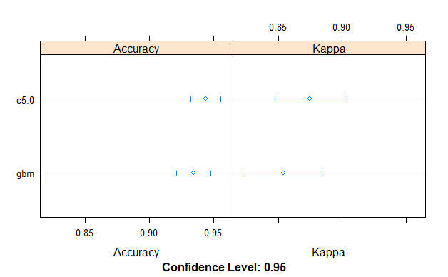

```r
dotplot(boosting)
```

C5.0 has an accuracy of 94.4%

We will do work on bagging algorithms now

We use Bagged CART and Random Forest

```r
control=trainControl(method="repeatedcv",number=10,repeats=3)
set.seed(110)
fit.treebag=train(V35~.,data=Iono_data,method="treebag",metric="Accuracy",trControl=control)
set.seed(110)
fit.rf=train(V35~.,data=Iono_data,method="rf",metric="Accuracy",trControl=control)
bagging_results=resamples(list(treebag=fit.treebag,rf=fit.rf))
summary(bagging_results)
```

```
Call:
summary.resamples(object = bagging_results)

Models: treebag, rf
Number of resamples: 30

Accuracy
             Min.   1st Qu.    Median      Mean   3rd Qu.      Max. NA's
treebag 0.8055556 0.8865079 0.9166667 0.9211422 0.9712185 0.9722222    0
rf      0.8571429 0.9117647 0.9428571 0.9307765 0.9440476 1.0000000    0

Kappa
            Min.   1st Qu.    Median      Mean   3rd Qu.      Max. NA's
treebag 0.556338 0.7466057 0.8184197 0.8246064 0.9369655 0.9407895    0
rf      0.676525 0.7990381 0.8736462 0.8470652 0.8780488 1.0000000    0
```

Random forest has an accuracy of 93%

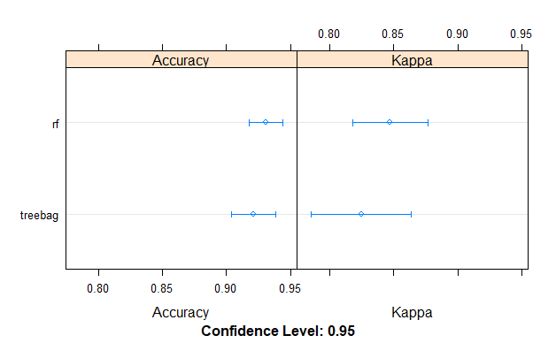

```r
dotplot(bagging_results)
```

Now we do Stacking,

caretEnsemble package combines multiple caret models, so given a list of caret models caretStack() function can be used to create a higher order model from the predictions of sub-models

We create 5 sub models for this dataset, they are 1. Linear Discriminate Analyis 2. Classificationa and Regression Trees 3. Logistic Regression 4. k-Nearest Neighbors 5. Support Vector Machines

```r
control=trainControl(method="repeatedcv",number=10,repeats=3,savePredictions=TRUE,classProbs = TRUE)
algo=c('lda','rpart','glm','knn','svmRadial')
set.seed(110)
models=caretList(V35~.,data=Iono_data,trControl=control,methodList=algo)
```

[output not shown]

```r
results=resamples(models)
summary(results)
```

```
Call:
summary.resamples(object = results)

Models: lda, rpart, glm, knn, svmRadial
Number of resamples: 30

Accuracy
               Min.   1st Qu.    Median      Mean   3rd Qu.      Max. NA's
lda       0.7714286 0.8285714 0.8571429 0.8623623 0.8880952 0.9444444    0
rpart     0.7777778 0.8333333 0.8571429 0.8700622 0.9142857 0.9705882    0
glm       0.7714286 0.8571429 0.8888889 0.8841643 0.9142857 0.9722222    0
knn       0.7222222 0.8071429 0.8571429 0.8434998 0.8601190 0.9705882    0
svmRadial 0.6571429 0.7818627 0.8285714 0.8262154 0.8785714 0.9444444    0

Kappa
               Min.   1st Qu.    Median      Mean   3rd Qu.      Max. NA's
lda       0.4488189 0.5945946 0.6679317 0.6751267 0.7411531 0.8813559    0
rpart     0.4440154 0.6353088 0.6891652 0.7085998 0.8088731 0.9368030    0
glm       0.4945848 0.6679317 0.7648511 0.7405794 0.8073394 0.9387755    0
knn       0.3308550 0.5433036 0.6653724 0.6297184 0.6788991 0.9343629    0
svmRadial 0.3655589 0.5805098 0.6645367 0.6614704 0.7529179 0.8834951    0
```

glm has an accuracy of 88.4%

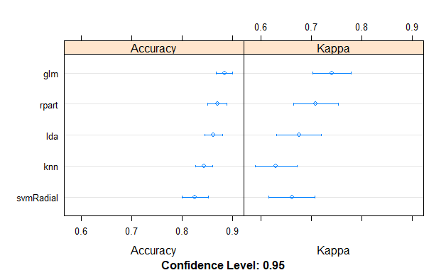

```r
dotplot(results)
```

when we combinme predictions of different models usng stacking, it is desirable that the predictions made by the sub-models have low correlation.

If the predictions for the submodels were highly corrected(>0.75) then they would be making the same or very similar predictions most of the time reducing the benefit of combining the predictions

```r
modelCor(results)
```

```
                 lda      rpart        glm        knn   svmRadial
lda       1.00000000 0.17796913  0.3515974  0.3669257  0.01437456
rpart     0.17796913 1.00000000  0.1166947  0.3301860  0.05524418
glm       0.35159735 0.11669469  1.0000000  0.1577639 -0.12911039
knn       0.36692571 0.33018602  0.1577639  1.0000000 -0.39483779
svmRadial 0.01437456 0.05524418 -0.1291104 -0.3948378  1.00000000
```

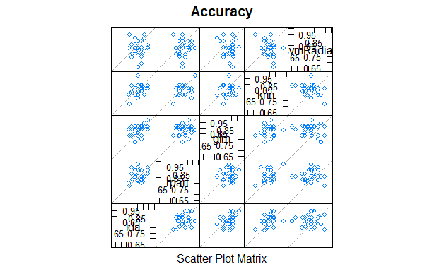

```r
splom(results)
```

```r
stackControl <- trainControl(method="repeatedcv", number=10, repeats=3, savePredictions=TRUE, classProbs=TRUE)
set.seed(110)
stack.glm <- caretStack(models, method="glm", metric="Accuracy", trControl=stackControl)
print(stack.glm)
```

```
A glm ensemble of 2 base models: lda, rpart, glm, knn, svmRadial

Ensemble results:
Generalized Linear Model

1053 samples
   5 predictor
   2 classes: 'b', 'g'

No pre-processing
Resampling: Cross-Validated (10 fold, repeated 3 times)
Summary of sample sizes: 947, 948, 948, 948, 948, 948, ...
Resampling results:

  Accuracy   Kappa
  0.9297358  0.8460003
```

This model lifted the accuracy to 92.9%

```r
# stack using random forest
set.seed(110)
stack.rf <- caretStack(models, method="rf", metric="Accuracy", trControl=stackControl)
print(stack.rf)
```

```
A rf ensemble of 2 base models: lda, rpart, glm, knn, svmRadial

Ensemble results:
Random Forest

1053 samples
   5 predictor
   2 classes: 'b', 'g'

No pre-processing
Resampling: Cross-Validated (10 fold, repeated 3 times)
Summary of sample sizes: 947, 948, 948, 948, 948, 948, ...
Resampling results across tuning parameters:

  mtry  Accuracy   Kappa
  2     0.9525183  0.8966748
  3     0.9525062  0.8966894
  5     0.9487176  0.8883695

Accuracy was used to select the optimal model using  the largest value.
The final value used for the model was mtry = 2.
```

This model lifted the accuracy to 95.2%